# Эвристики: методы поиска решений в условиях неопределённости

Доклад по дисциплине «Имитационное моделирование»

Закиров Нурислам Дамирович

1132236040@rudn.ru

Российский университет дружбы народов

2026-04-02

# Титульный слайд

## Эвристики: методы поиска решений в условиях неопределённости

**Доклад по дисциплине «Имитационное моделирование»**

## Докладчик

- **Закиров Нурислам Дамирович**
- студент группы НФИбд-01-23
- Российский университет дружбы народов
- 1132236040@rudn.ru

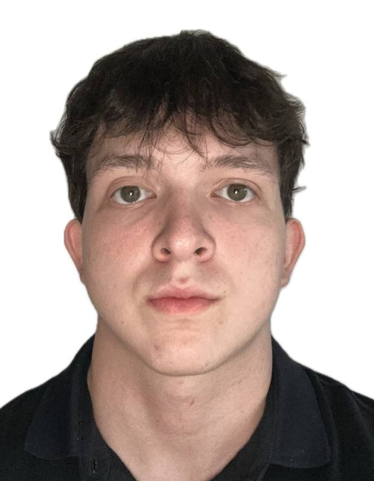

# Цель и структура доклада

## Цель доклада

Комплексный анализ эвристик как методов поиска решений в условиях неопределённости

## План выступления

1. Понятие и сущность эвристик
2. Три типа эвристических моделей
3. Когнитивные эвристики и искажения
4. Две системы мышления
5. Применение эвристик
6. Практические рекомендации
7. Выводы

# Понятие эвристики

## Определение

**Эвристика** (от греч. *heurisko* — «нахожу») — практический метод решения задач, не гарантирующий оптимальности, но позволяющий найти удовлетворительное решение за приемлемое время

## Ключевые характеристики

| Характеристика | Суть |
| --- | --- |
| **Упрощение** | Замена сложных вопросов простыми |
| **Скорость** | Быстрое принятие решений |
| **Экономность** | Минимум когнитивных ресурсов |
| **Адаптивность** | Приспособлены к среде |

## Эвристика как наука

Занимается построением моделей процесса поиска оригинального решения задачи

# Типы эвристических моделей

### 1. Модель слепого поиска

Метод проб и ошибок без предварительной стратегии

**Пример:** ребёнок собирает пазл подбором

### 2. Лабиринтная модель

Задача как лабиринт, поиск — как блуждание

**Эвристика:** правило правой руки

### 3. Структурно-семантическая модель

Построение системы моделей с семантическими связями

**Приёмы:** аналогия, декомпозиция

[figure not shown]

# Сравнение эвристик и алгоритмов

| Критерий | Алгоритмы | Эвристики |
| --- | --- | --- |
| Гарантия | ✅ Гарантируют | ❌ Не гарантируют |
| Время | Долгое | Быстрое |
| Данные | Полные | Неполные |
| Сложность | Высокая | Низкая |

[figure not shown]

# Когнитивные эвристики

## Три основные эвристики (Тверски и Канеман, 1974)

**1. Эвристика доступности**

Оценка по лёгкости вспоминания

*Пример:* переоценка риска авиакатастроф после новостей

**2. Эвристика репрезентативности**

Оценка по сходству с прототипом

*Пример:* ошибка конъюнкции («Линда»)

**3. Эвристика якорения**

Зависимость от первоначальной информации

*Пример:* первая цена на переговорах

# Две системы мышления

## Система 1 и Система 2 (Канеман, 2011)

**Система 1**

- Быстрая
- Автоматическая
- Без усилий
- Использует эвристики
- Подвержена искажениям

[figure not shown]

**Система 2**

- Медленная
- Аналитическая
- Требует усилий
- Использует логику
- Менее искажена

**95% решений** принимается Системой 1

# Применение эвристик

| Область | Примеры применения |
| --- | --- |
| **Психология** | Изучение принятия решений, когнитивно-поведенческая терапия |
| **ИИ** | Поисковые алгоритмы (A*), машинное обучение, экспертные системы |
| **Образование** | Метод 6 вопросов, мозговой штурм, синектика |
| **Бизнес** | Правило 80/20, SWOT-анализ, BCG-матрица |

[figure not shown]

# Практические рекомендации

## Для индивидуальных решений

1. **Осознавайте** используемые эвристики
2. **Проверяйте якоря** на релевантность
3. **Используйте множественные источники**
4. **Применяйте 6 вопросов** для структурирования
5. **Давайте время** на размышление для важных решений

## Для организаций

- Обучайте сотрудников
- Стандартизируйте повторяющиеся процессы
- Поощряйте разнообразие мнений
- Ведите журнал решений

[figure not shown]

# Выводы

## Основные результаты

1. ✅ **Эвристики** — фундаментальный инструмент мышления в условиях неопределённости
2. ✅ **3 типа моделей:** слепого поиска, лабиринтная, структурно-семантическая
3. ✅ **Когнитивные эвристики** могут приводить к искажениям
4. ✅ **Понимание механизмов** минимизирует ошибки
5. ✅ **Применение:** психология, ИИ, образование, бизнес

## Практическая значимость

- Образовательные программы по критическому мышлению
- Тренинги для менеджеров
- Системы поддержки принятия решений

[figure not shown]

# Спасибо за внимание!

## Вопросы?

**Контакты:**

Закиров Нурислам Дамирович  
НФИбд-01-23, РУДН  
1132236040@rudn.ru